# Ejemplos en R

## *Applied Longitudinal Data Analysis: Modeling Change and Event Occurrence* by Judith D. Singer and John B. Willett

### Chapter 11: Fitting basic discrete-time hazard models

Los ejemplos fueron escritos usando R, versión 2.4.1. Se requiere el paquete `survival`.

```r
library(survival)
```

Figure 11.1, page 359

```r
firstsex<-read.table("https://stats.idre.ucla.edu/stat/examples/alda/firstsex.csv", sep=",", header=T)
ts0 <- survfit( Surv(time, 1-censor)~ 1, conf.type="none", subset=(pt==0), data=firstsex)
ts1 <- survfit( Surv(time, 1-censor)~ 1, conf.type="none", subset=(pt==1), data=firstsex)
h0<-ts0$n.event/ts0$n.risk
h1<-ts1$n.event/ts1$n.risk
plot(ts0$time, h0, type="l", ylab="Estimated Hazard probability", xlab="Grade",
     ylim=c(0.0, 0.5), xlim=c(6, 12), col="red")
par(new=T)
```

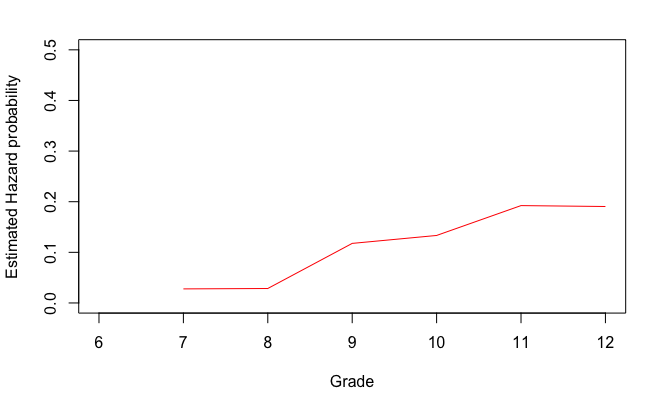

```r
plot(ts1$time, h1, type="l", ylab=" ", ylim=c(0.0, 0.5), xlim=c(6, 12), xlab="", col="blue")
```

```r
plot(ts0$time, ts0$surv, type="l", ylab="Estimated Survival Function", xlab="Grade",
     ylim=c(0.0, 1.0), xlim=c(6, 12), col="red")
par(new=T)
```

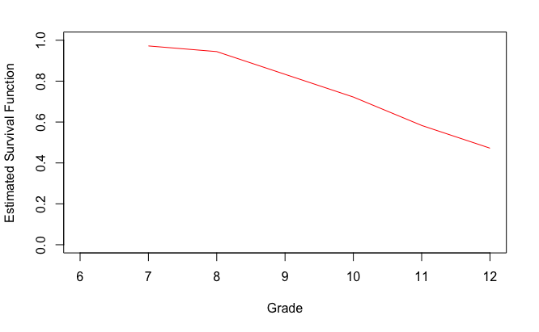

```r
plot(ts1$time, ts1$surv, type="l", ylab=" ", ylim=c(0.0, 1.0), xlim=c(6, 12), xlab="", col="blue")
abline(h=c(.5), lty=2)
```

Table 11.1, page 360. Crearemos la tabla en dos partes. La primera está basada en el resultado del ejemplo anterior.

```r
tab11.1.0<-cbind(time=ts0$time, nleft=ts0$n.risk, failed=ts0$n.event, hazard=h0, survival=ts0$surv)
tab11.1.1<-cbind(time=ts1$time, nleft=ts1$n.risk, failed=ts1$n.event, hazard=h1, survival=ts1$surv)
tab11.1 <-rbind(tab11.1.0, tab11.1.1)
tab11.1
```

```
      time nleft failed     hazard  survival
 [1,]    7    72      2 0.02777778 0.9722222
 [2,]    8    70      2 0.02857143 0.9444444
 [3,]    9    68      8 0.11764706 0.8333333
 [4,]   10    60      8 0.13333333 0.7222222
 [5,]   11    52     10 0.19230769 0.5833333
 [6,]   12    42      8 0.19047619 0.4722222
 [7,]    7   108     13 0.12037037 0.8796296
 [8,]    8    95      5 0.05263158 0.8333333
 [9,]    9    90     16 0.17777778 0.6851852
[10,]   10    74     21 0.28378378 0.4907407
[11,]   11    53     15 0.28301887 0.3518519
[12,]   12    38     18 0.47368421 0.1851852
```

```r
tsall <- survfit( Surv(time, 1-censor)~ 1, conf.type="none", data=firstsex)
h<-tsall$n.event/tsall$n.risk
tab11.1.all<-cbind(time=tsall$time, nleft=tsall$n.risk, failed=tsall$n.event, hazard=h, survival=tsall$surv)
tab11.1.all
```

```
     time nleft failed     hazard  survival
[1,]    7   180     15 0.08333333 0.9166667
[2,]    8   165      7 0.04242424 0.8777778
[3,]    9   158     24 0.15189873 0.7444444
[4,]   10   134     29 0.21641791 0.5833333
[5,]   11   105     25 0.23809524 0.4444444
[6,]   12    80     26 0.32500000 0.3000000
```

Figure 11.2, page 363

Usaremos las variables creadas para el ejemplo anterior que contiene la función hazard creada para la Figure 11.1 con el fin de producir los odds estimados y el logit(hazard) estimado.

```r
odds0<-h0/(1-h0)
odds1<-h1/(1-h1)
logith0<-log(odds0)
logith1<-log(odds1)
plot(ts0$time, h0, type="l", ylab="Estimated Hazard Probability", xlab="Grade",
     ylim=c(0.0, 1), xlim=c(6, 12), col="red")
par(new=T)
```

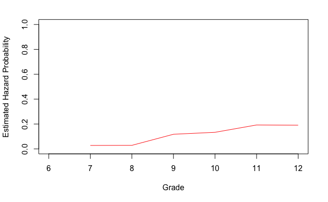

```r
plot(ts1$time, h1, type="l", ylab=" ", ylim=c(0.0, 1), xlim=c(6, 12), xlab="", col="blue")
```

```r
plot(ts0$time, odds0, type="l", ylab="Estimated Odds", xlab="Grade",
     ylim=c(0,1), xlim=c(6, 12), col="red")
par(new=T)
```

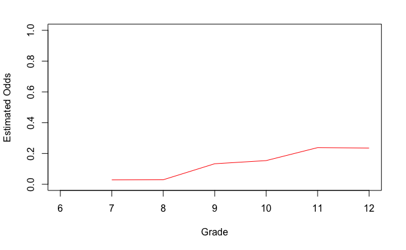

```r
plot(ts1$time, odds1, type="l", ylab=" ", ylim=c(0, 1), xlim=c(6, 12), xlab="", col="blue")
```

```r
plot(ts0$time, logith0, type="l", ylab="Estimated Logit", xlab="Grade",
     ylim=c(-4, 0), xlim=c(6, 12), col="red")
par(new=T)
```

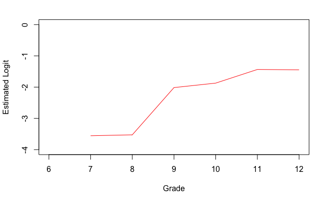

```r
plot(ts1$time, logith1, type="l", ylab=" ", ylim=c(-4, 0), xlim=c(6, 12), xlab="", col="blue")
```

Figure 11.3 on page 366.

Panel A: logit hazard es horizontal con el tiempo.

```r
firstsex.pp<-read.table("https://stats.idre.ucla.edu/stat/examples/alda/firstsex_pp.csv", sep=",", header=T)
afit <- glm(event ~ pt, family="binomial", data=firstsex.pp)
summary(afit)
```

```
Call:
glm(formula = event ~ pt, family = "binomial", data = firstsex.pp)

Deviance Residuals:
    Min       1Q   Median       3Q      Max
-0.6532  -0.6532  -0.4696  -0.4696   2.1258

Coefficients:
            Estimate Std. Error z value Pr(>|z|)
(Intercept)  -2.1493     0.1714 -12.539  < 2e-16 ***
pt            0.7131     0.2084   3.421 0.000623 ***
---
Signif. codes:  0 ‘***’ 0.001 ‘**’ 0.01 ‘*’ 0.05 ‘.’ 0.1 ‘ ’ 1

(Dispersion parameter for binomial family taken to be 1)

    Null deviance: 704.23  on 821  degrees of freedom
Residual deviance: 691.82  on 820  degrees of freedom
AIC: 695.82

Number of Fisher Scoring iterations: 4
```

```r
t<-data.frame(afit$coefficients)
p0<-t[1,1]
p1<-p0+t[2,1]
firstsex<-read.table("https://stats.idre.ucla.edu/stat/examples/alda/firstsex.csv", sep=",", header=T)
ts0 <- survfit( Surv(time, 1-censor)~ 1, conf.type="none", subset=(pt==0), data=firstsex)
ts1 <- survfit( Surv(time, 1-censor)~ 1, conf.type="none", subset=(pt==1), data=firstsex)
h0<-ts0$n.event/ts0$n.risk
h1<-ts1$n.event/ts1$n.risk
odds0<-h0/(1-h0)
odds1<-h1/(1-h1)
logith0<-log(odds0)
logith1<-log(odds1)
plot(ts0$time, logith0, type="p", ylab="Estimated Logit", xlab="Grade",
     ylim=c(-4, 0), xlim=c(6, 12), col="red")
par(new=T)
```

```r
plot(ts1$time, logith1, type="p", ylab=" ", ylim=c(-4, 0), xlim=c(6, 12), xlab="", col="blue")
abline(h=c(p0), lty=1, col="red")
```

[figure not shown]

```r
abline(h=c(p1), lty=1, col="blue")
```

Panel B: logit hazard es lineal con el tiempo

```r
afit2<-glm(event~pt + period, family="binomial", data=firstsex.pp)
summary(afit2)
```

```
Call:
glm(formula = event ~ pt + period, family = "binomial", data = firstsex.pp)

Deviance Residuals:
    Min       1Q   Median       3Q      Max
-1.0653  -0.6177  -0.4128  -0.3329   2.5813

Coefficients:
            Estimate Std. Error z value Pr(>|z|)
(Intercept) -6.30534    0.67034  -9.406  < 2e-16 ***
pt           0.87544    0.21696   4.035 5.46e-05 ***
period       0.43003    0.06407   6.712 1.92e-11 ***
---
Signif. codes:  0 ‘***’ 0.001 ‘**’ 0.01 ‘*’ 0.05 ‘.’ 0.1 ‘ ’ 1

(Dispersion parameter for binomial family taken to be 1)

    Null deviance: 704.23  on 821  degrees of freedom
Residual deviance: 643.13  on 819  degrees of freedom
AIC: 649.13

Number of Fisher Scoring iterations: 5
```

```r
t<-data.frame(afit2$coefficients)
y0<-t[1,1] + t[3,1]*ts0$time
y1<-t[1,1] + t[2,1] + t[3,1]*ts0$time
plot(ts0$time, logith0, type="p", ylab="Estimated Logit", xlab="Grade",
     ylim=c(-4, 0), xlim=c(6, 12), col="red")
par(new=T)
```

```r
plot(ts1$time, logith1, type="p", ylab=" ", ylim=c(-4, 0), xlim=c(6, 12), xlab="", col="blue")
par(new=T)
```

```r
plot(ts1$time, y0, type="l", ylab=" ", ylim=c(-4, 0), xlim=c(6, 12), xlab="", col="red")
par(new=T)
```

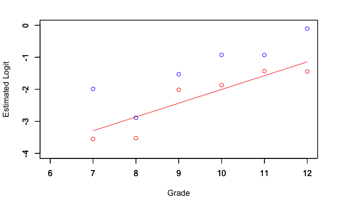

```r
plot(ts1$time, y1, type="l", ylab=" ", ylim=c(-4, 0), xlim=c(6, 12), xlab="", col="blue")
```

Panel C: Logit hazard es completamente general con el tiempo.

```r
afit3<-glm(event~pt + factor(period), family="binomial", data=firstsex.pp)
summary(afit3)
```

```
Call:
glm(formula = event ~ pt + factor(period), family = "binomial",
    data = firstsex.pp)

Deviance Residuals:
    Min       1Q   Median       3Q      Max
-1.0508  -0.6617  -0.4411  -0.3126   2.7293

Coefficients:
                 Estimate Std. Error z value Pr(>|z|)
(Intercept)       -2.9943     0.3175  -9.431  < 2e-16 ***
pt                 0.8736     0.2174   4.018 5.86e-05 ***
factor(period)8   -0.7058     0.4728  -1.493 0.135514
factor(period)9    0.7132     0.3519   2.027 0.042667 *
factor(period)10   1.1717     0.3452   3.394 0.000689 ***
factor(period)11   1.3401     0.3588   3.735 0.000188 ***
factor(period)12   1.8153     0.3674   4.941 7.78e-07 ***
---
Signif. codes:  0 ‘***’ 0.001 ‘**’ 0.01 ‘*’ 0.05 ‘.’ 0.1 ‘ ’ 1

(Dispersion parameter for binomial family taken to be 1)

    Null deviance: 704.23  on 821  degrees of freedom
Residual deviance: 634.66  on 815  degrees of freedom
AIC: 648.66

Number of Fisher Scoring iterations: 5
```

```r
t<-data.frame(cbind(y=afit3$linear.predictors, time=firstsex.pp$period, pt=firstsex.pp$pt))
t0<-t[t$pt==0,]
t0<-t0[order(t0$time),]
t1<-t[t$pt==1,]
t1<-t1[order(t1$time),]
plot(ts0$time, logith0, type="p", ylab="Estimated Logit", xlab="Grade",
     ylim=c(-4, 0), xlim=c(6, 12), col="red")
par(new=T)
```

```r
plot(ts1$time, logith1, type="p", ylab=" ", ylim=c(-4, 0), xlim=c(6, 12), xlab="", col="blue")
par(new=T)
```

```r
plot(t0$time, t0$y, type="l", ylab=" ", ylim=c(-4, 0), xlim=c(6, 12), xlab="", col="red")
par(new=T)
```

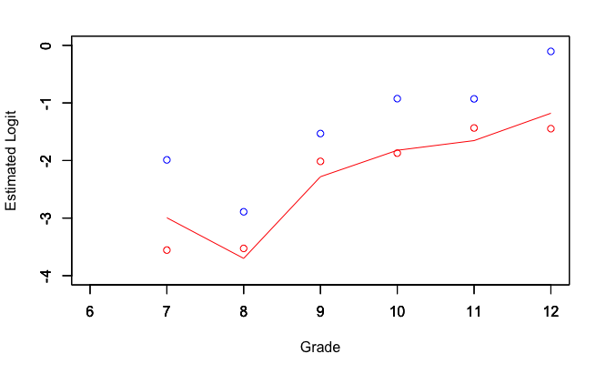

```r
plot(t1$time, t1$y, type="l", ylab=" ", ylim=c(-4, 0), xlim=c(6, 12), xlab="", col="blue")
```

Figure 11.4, page 374

Panel A:

```r
afit3<-glm(event~pt + factor(period), family="binomial", data=firstsex.pp)
t<-data.frame(cbind(y=afit3$linear.predictors, time=firstsex.pp$period, pt=firstsex.pp$pt))
t0<-t[t$pt==0,]
t0<-t0[order(t0$time),]
t1<-t[t$pt==1,]
t1<-t1[order(t1$time),]
plot(t0$time, t0$y, type="b", ylab=" ", ylim=c(-4, 0), xlim=c(6, 12), xlab="", col="red")
par(new=T)
```

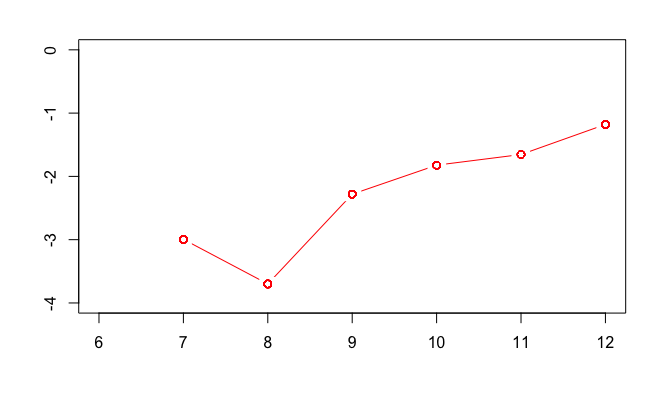

```r
plot(t1$time, t1$y, type="b", ylab=" ", ylim=c(-4, 0), xlim=c(6, 12), xlab="", col="blue")
```

Panel B:

```r
afit4<-glm(event~pt + factor(period) + pt*factor(period), family="binomial", data=firstsex.pp)
t<-data.frame(cbind(y=exp(afit4$linear.predictors), time=firstsex.pp$period, pt=firstsex.pp$pt))
t0<-t[t$pt==0,]
t0<-t0[order(t0$time),]
t1<-t[t$pt==1,]
t1<-t1[order(t1$time),]
plot(t0$time, t0$y, type="b", ylab="Odds", ylim=c(0, 1), xlim=c(6, 12), xlab="", col="red")
par(new=T)
```

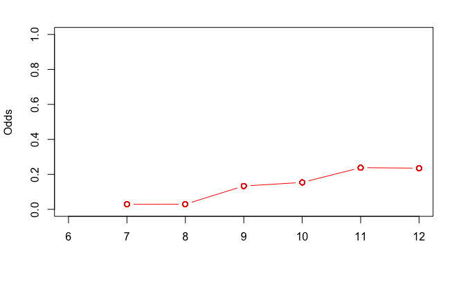

```r
plot(t1$time, t1$y, type="b", ylab=" ", ylim=c(0, 1), xlim=c(6, 12), xlab="", col="blue")
```

Panel C

```r
t<-data.frame(cbind(y=afit4$fitted.values, time=firstsex.pp$period, pt=firstsex.pp$pt))
t0<-t[t$pt==0,]
t0<-t0[order(t0$time),]
t1<-t[t$pt==1,]
t1<-t1[order(t1$time),]
plot(t0$time, t0$y, type="b", ylab="Hazard", ylim=c(0, .5), xlim=c(6, 12), xlab="", col="red")
par(new=T)
```

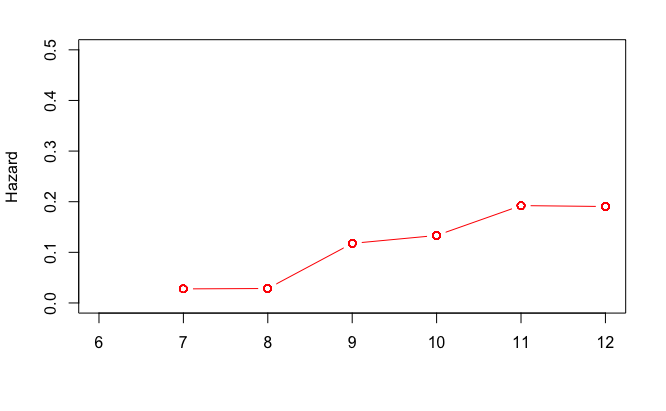

```r
plot(t1$time, t1$y, type="b", ylab=" ", ylim=c(0, .5), xlim=c(6, 12), xlab="", col="blue")
```

Tabla 11.3, página 386. Observe que para realizar el deviance test, a veces debemos ejecutar el modelo varias veces, una para cada variable que se prueba, ya que la variable que se está probando debe aparecer al final del modelo.

Model A:

```r
modelA<-glm(event~factor(period) - 1, family="binomial", data=firstsex.pp)
summary(modelA)
```

```
Call:
glm(formula = event ~ factor(period) - 1, family = "binomial",
    data = firstsex.pp)

Deviance Residuals:
    Min       1Q   Median       3Q      Max
-0.8866  -0.6984  -0.4172  -0.2944   2.5140

Coefficients:
                 Estimate Std. Error z value Pr(>|z|)
factor(period)7   -2.3979     0.2697  -8.892  < 2e-16 ***
factor(period)8   -3.1167     0.3862  -8.071 7.00e-16 ***
factor(period)9   -1.7198     0.2217  -7.759 8.56e-15 ***
factor(period)10  -1.2867     0.2098  -6.133 8.60e-10 ***
factor(period)11  -1.1632     0.2291  -5.076 3.85e-07 ***
factor(period)12  -0.7309     0.2387  -3.062   0.0022 **
---
Signif. codes:  0 ‘***’ 0.001 ‘**’ 0.01 ‘*’ 0.05 ‘.’ 0.1 ‘ ’ 1

(Dispersion parameter for binomial family taken to be 1)

    Null deviance: 1139.53  on 822  degrees of freedom
Residual deviance:  651.96  on 816  degrees of freedom
AIC: 663.96

Number of Fisher Scoring iterations: 5
```

Model B:

```r
modelB<-glm(event~factor(period) + pt - 1, family="binomial", data=firstsex.pp)
summary(modelB)
```

```
Call:
glm(formula = event ~ factor(period) + pt - 1, family = "binomial",
    data = firstsex.pp)

Deviance Residuals:
    Min       1Q   Median       3Q      Max
-1.0508  -0.6617  -0.4411  -0.3126   2.7293

Coefficients:
                 Estimate Std. Error z value Pr(>|z|)
factor(period)7   -2.9943     0.3175  -9.431  < 2e-16 ***
factor(period)8   -3.7001     0.4205  -8.800  < 2e-16 ***
factor(period)9   -2.2811     0.2724  -8.374  < 2e-16 ***
factor(period)10  -1.8226     0.2585  -7.052 1.77e-12 ***
factor(period)11  -1.6542     0.2691  -6.147 7.89e-10 ***
factor(period)12  -1.1791     0.2716  -4.341 1.42e-05 ***
pt                 0.8736     0.2174   4.018 5.86e-05 ***
---
Signif. codes:  0 ‘***’ 0.001 ‘**’ 0.01 ‘*’ 0.05 ‘.’ 0.1 ‘ ’ 1

(Dispersion parameter for binomial family taken to be 1)

    Null deviance: 1139.53  on 822  degrees of freedom
Residual deviance:  634.66  on 815  degrees of freedom
AIC: 648.66

Number of Fisher Scoring iterations: 5
```

```r
anova(modelB)
```

```
Analysis of Deviance Table

Model: binomial, link: logit

Response: event

Terms added sequentially (first to last)

               Df Deviance Resid. Df Resid. Dev
NULL                             822    1139.53
factor(period)  6   487.58       816     651.96
pt              1    17.29       815     634.66
```

Model C:

```r
modelC<-glm(event~factor(period) + pas - 1, family="binomial", data=firstsex.pp)
summary(modelC)
```

```
Call:
glm(formula = event ~ factor(period) + pas - 1, family = "binomial",
    data = firstsex.pp)

Deviance Residuals:
    Min       1Q   Median       3Q      Max
-1.1548  -0.6360  -0.4475  -0.2725   2.6829

Coefficients:
                 Estimate Std. Error z value Pr(>|z|)
factor(period)7   -2.4646     0.2741  -8.991  < 2e-16 ***
factor(period)8   -3.1591     0.3889  -8.123 4.55e-16 ***
factor(period)9   -1.7297     0.2245  -7.705 1.31e-14 ***
factor(period)10  -1.2851     0.2127  -6.043 1.51e-09 ***
factor(period)11  -1.1360     0.2324  -4.889 1.01e-06 ***
factor(period)12  -0.6421     0.2428  -2.644 0.008187 **
pas                0.4428     0.1140   3.886 0.000102 ***
---
Signif. codes:  0 ‘***’ 0.001 ‘**’ 0.01 ‘*’ 0.05 ‘.’ 0.1 ‘ ’ 1

(Dispersion parameter for binomial family taken to be 1)

    Null deviance: 1139.53  on 822  degrees of freedom
Residual deviance:  637.17  on 815  degrees of freedom
AIC: 651.17

Number of Fisher Scoring iterations: 5
```

```r
anova(modelC)
```

```
Analysis of Deviance Table

Model: binomial, link: logit

Response: event

Terms added sequentially (first to last)

               Df Deviance Resid. Df Resid. Dev
NULL                             822    1139.53
factor(period)  6   487.58       816     651.96
pas             1    14.79       815     637.17
```

Modelo D

```r
modelD<-glm(event~factor(period) + pt + pas - 1, family="binomial", data=firstsex.pp)
summary(modelD)
```

```
Call:
glm(formula = event ~ factor(period) + pt + pas - 1, family = "binomial",
    data = firstsex.pp)

Deviance Residuals:
    Min       1Q   Median       3Q      Max
-1.1787  -0.6182  -0.4338  -0.2836   2.7862

Coefficients:
                 Estimate Std. Error z value Pr(>|z|)
factor(period)7   -2.8932     0.3206  -9.024  < 2e-16 ***
factor(period)8   -3.5848     0.4230  -8.474  < 2e-16 ***
factor(period)9   -2.1502     0.2775  -7.750 9.20e-15 ***
factor(period)10  -1.6932     0.2646  -6.398 1.58e-10 ***
factor(period)11  -1.5177     0.2757  -5.504 3.71e-08 ***
factor(period)12  -1.0099     0.2811  -3.592 0.000328 ***
pt                 0.6605     0.2367   2.790 0.005266 **
pas                0.2964     0.1254   2.364 0.018089 *
---
Signif. codes:  0 ‘***’ 0.001 ‘**’ 0.01 ‘*’ 0.05 ‘.’ 0.1 ‘ ’ 1

(Dispersion parameter for binomial family taken to be 1)

    Null deviance: 1139.53  on 822  degrees of freedom
Residual deviance:  629.15  on 814  degrees of freedom
AIC: 645.15

Number of Fisher Scoring iterations: 5
```

```r
modelD<-glm(event~factor(period) + pas + pt - 1, family="binomial", data=firstsex.pp)
anova(modelD)
```

```
Analysis of Deviance Table

Model: binomial, link: logit

Response: event

Terms added sequentially (first to last)

               Df Deviance Resid. Df Resid. Dev
NULL                             822    1139.53
factor(period)  6   487.58       816     651.96
pas             1    14.79       815     637.17
pt              1     8.02       814     629.15
```

```r
modelD<-glm(event~factor(period) + pt + pas - 1, family="binomial", data=firstsex.pp)
anova(modelD)
```

```
Analysis of Deviance Table

Model: binomial, link: logit

Response: event

Terms added sequentially (first to last)

               Df Deviance Resid. Df Resid. Dev
NULL                             822    1139.53
factor(period)  6   487.58       816     651.96
pt              1    17.29       815     634.66
pas             1     5.51       814     629.15
```

Table 11.4, page 388

```r
modelA<-glm(event~factor(period) - 1, family="binomial", data=firstsex.pp)
col0<-c(7:12)
col1<-c("D7", "D8", "D9", "D10", "D11", "D12")
col2<-exp(modelA$coefficients)
col3<- 1 /(1+exp(-modelA$coefficients))
tab11.4<-data.frame(time=col0, Predictor=col1, parameter=modelA$coefficients,
         fitted.odds=col2, fitted.hazard=col3, row.names=NULL)
tab11.4
```

| time | Predictor | parameter | fitted.odds | fitted.hazard |
| --- | --- | --- | --- | --- |
| 7 | D7 | -2.3978953 | 0.09090909 | 0.08333333 |
| 8 | D8 | -3.1166848 | 0.04430380 | 0.04242425 |
| 9 | D9 | -1.7197860 | 0.17910448 | 0.15189873 |
| 10 | D10 | -1.2866645 | 0.27619048 | 0.21641791 |
| 11 | D11 | -1.1631508 | 0.31250000 | 0.23809524 |
| 12 | D12 | -0.7308875 | 0.48148148 | 0.32500000 |

Table 11.5 on page 392 based on Model B.

```r
modelB<-glm(event~factor(period) + pt - 1, family="binomial", data=firstsex.pp)
t<-data.frame(hazard=modelB$fitted.values, time=firstsex.pp$period, pt=firstsex.pp$pt)
t$logit<-log(t$hazard/(1-t$hazard))
ta<-aggregate(t, list(pt=t$pt, time=t$time),mean)
ta.0<-ta[ta$pt==0, ]
ta.1<-ta[ta$pt==1, ]
c1<-c(7:12)
c2<-ta.0$logit
c3<-ta.1$logit-ta.0$logit
c4<-ta.0$logit
c5<-ta.1$logit
c6<-ta.0$hazard
c7<-ta.1$hazard
tab11.5<-data.frame(time=c1, alpha=c2, beta=c3, logit_0=c4, logit_1=c5, hazard_0=c6, hazard_1=c7)
tab11.5$surv_0<-c(1:6)
tab11.5$surv_1<-c(1:6)
tab11.5$surv_0[1]<-1-tab11.5$hazard_0[1]
tab11.5$surv_1[1]<-1-tab11.5$hazard_1[1]
for(i in 2:6) {
tab11.5$surv_0[i] = tab11.5$surv_0[i-1]*(1-tab11.5$hazard_0[i])
tab11.5$surv_1[i] = tab11.5$surv_1[i-1]*(1-tab11.5$hazard_1[i])
 }
tab11.5
```

| time | alpha | beta | logit_0 | logit_1 | hazard_0 | hazard_1 | surv_0 | surv_1 |
| --- | --- | --- | --- | --- | --- | --- | --- | --- |
| 7 | -2.994327 | 0.8736184 | -2.994327 | -2.1207082 | 0.04768284 | 0.10710033 | 0.9523172 | 0.8928997 |
| 8 | -3.700124 | 0.8736184 | -3.700124 | -2.8265055 | 0.02412410 | 0.05590856 | 0.9293434 | 0.8429789 |
| 9 | -2.281124 | 0.8736184 | -2.281124 | -1.4075051 | 0.09269841 | 0.19662787 | 0.8431947 | 0.6772258 |
| 10 | -1.822599 | 0.8736184 | -1.822599 | -0.9489801 | 0.13912236 | 0.27908998 | 0.7258875 | 0.4882189 |
| 11 | -1.654227 | 0.8736184 | -1.654227 | -0.7806088 | 0.16053845 | 0.31418869 | 0.6093546 | 0.3348260 |
| 12 | -1.179057 | 0.8736184 | -1.179057 | -0.3054385 | 0.23522180 | 0.42422854 | 0.4660211 | 0.1927833 |

Figura 11.6, página 393 usando el Modelo B. Los datos para los gráficos, tab11.5, se han creado en el ejemplo anterior.

```r
plot(tab11.5$time, tab11.5$logit_0, type="l", ylab="Fitted logit(hazard)",
     ylim=c(-4, 0), xlim=c(6, 12), xlab="", col="red")
par(new=T)
```

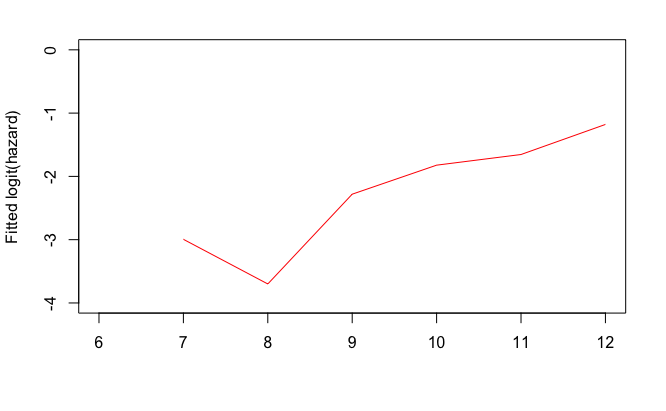

```r
plot(tab11.5$time, tab11.5$logit_1, type="l", ylab="", ylim=c(-4, 0), xlim=c(6, 12), xlab="", col="blue")
```

```r
plot(tab11.5$time, tab11.5$hazard_0, type="l", ylab="Fitted hazard",
     ylim=c(0, 0.5), xlim=c(6, 12), xlab="", col="red")
par(new=T)
```

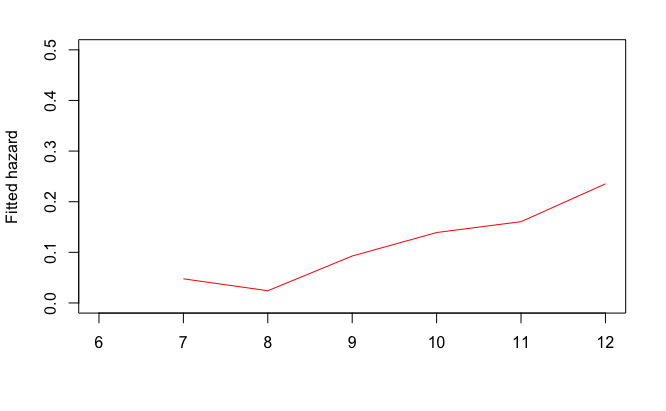

```r
plot(tab11.5$time, tab11.5$hazard_1, type="l", ylab="", ylim=c(0, 0.5), xlim=c(6, 12), xlab="", col="blue")
```

```r
plot(tab11.5$time, tab11.5$surv_0, type="l", ylab="Fitted survival probability",
     ylim=c(0, 1), xlim=c(6, 12), xlab="", col="red")
par(new=T)
```

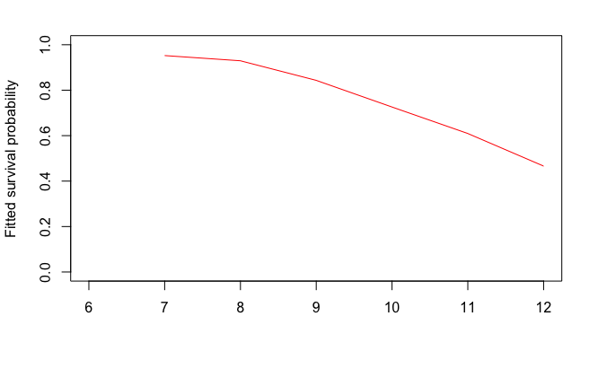

```r
plot(tab11.5$time, tab11.5$surv_1, type="l", ylab="", ylim=c(0,1), xlim=c(6, 12), xlab="", col="blue")
abline(h=c(.5), lty=2)
```

Figure 11.7 de la página 395 basado en el Model D.

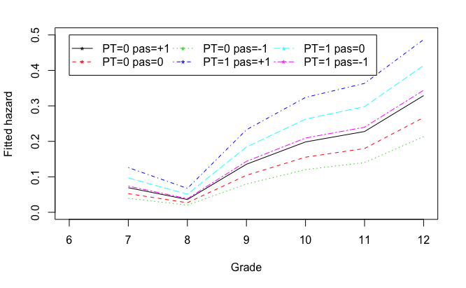

```r
modelD<-glm(event~factor(period) + pt + pas - 1, family="binomial", data=firstsex.pp)
coeff<-data.frame(modelD$coefficients)
myt<-c(1:6)
h0_pas1<-c(1:6)
h0_pas0<-c(1:6)
h0_pasn1<-c(1:6)
h1_pas1<-c(1:6)
h1_pas0<-c(1:6)
h1_pasn1<-c(1:6)
for(i in 1:6) {
myt[i]<-i+6
h0_pas1[i]<-1/(1+ exp(-(coeff[i,] + coeff[8,])))
h0_pas0[i]<-1/(1+ exp(-coeff[i,]))
h0_pasn1[i]<-1/(1+ exp(-(coeff[i,] - coeff[8,])))
h1_pas1[i]<-1/(1+ exp(-(coeff[i,] + coeff[8,] + coeff[7,])))
h1_pas0[i]<-1/(1+ exp(-(coeff[i,] + coeff[7,])))
h1_pasn1[i]<-1/(1+ exp(-(coeff[i,] - coeff[8,] + coeff[7,])))
}
f<-cbind(h0_pas1,h0_pas0,h0_pasn1, h1_pas1,h1_pas0,h1_pasn1)
matplot(myt, f, type="l", ylab="Fitted hazard", ylim=c(0, 0.5), xlim=c(6, 12),
     xlab="Grade", col=1:6, lty=1:6)
legend(6, .5, c("PT=0 pas=+1", "PT=0 pas=0", "PT=0 pas=-1",
                "PT=1 pas=+1", "PT=1 pas=0", "PT=1 pas=-1"),
                col=1:6, lty=1:6, pch = "*",
                ncol =3, cex = 1)
```

```r
surv0_pas1<-c(1:6)
surv0_pas0<-c(1:6)
surv0_pasn1<-c(1:6)
surv1_pas1<-c(1:6)
surv1_pas0<-c(1:6)
surv1_pasn1<-c(1:6)
surv0_pas1[1]<-1-h0_pas1[1]
surv0_pas0<-1-h0_pas0[1]
surv0_pasn1<-1-h0_pasn1[1]
surv1_pas1<-1-h1_pas1[1]
surv1_pas0<-1-h1_pas1[1]
surv1_pasn1<-1-h1_pas1[1]
for(i in 2:6) {
surv0_pas1[i] = surv0_pas1[i-1]*(1-h0_pas1[i])
surv0_pas0[i] = surv0_pas0[i-1]*(1-h0_pas0[i])
surv0_pasn1[i] = surv0_pasn1[i-1]*(1-h0_pasn1[i])
surv1_pas1[i] = surv1_pas1[i-1]*(1-h1_pas1[i])
surv1_pas0[i] = surv1_pas0[i-1]*(1-h1_pas0[i])
surv1_pasn1[i] = surv1_pasn1[i-1]*(1-h1_pasn1[i])
 }
s<-cbind(surv0_pas1,surv0_pas0,surv0_pasn1,surv1_pas1,surv1_pas0,surv1_pasn1)
matplot(myt, s, type="l", ylab="Fitted survival probability", ylim=c(0, 1), xlim=c(6, 12),
     xlab="Grade", col=1:6, lty=1:6)
abline(h=c(.5), lty=2)
```

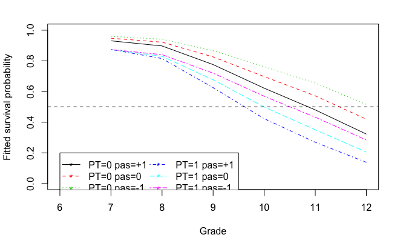

```r
legend(6, .2, c("PT=0 pas=+1", "PT=0 pas=0", "PT=0 pas=-1",
                "PT=1 pas=+1", "PT=1 pas=0", "PT=1 pas=-1"),
                col=1:6, lty=1:6, pch = "*",
                ncol =2, cex = 1)
```